# Distributions homework

## MVP

### Question 1

**Load the data, `clean_names()` and explore it.**

First load the required libraries

```r
library(tidyverse)
library(janitor)
```

Read in the data and have a quick look.

```r
phone_data <- read_csv("data/20190928-items.csv") %>%
  clean_names()
glimpse(phone_data)
```

```
## Rows: 792
## Columns: 9
## $ asin          <chr> "B0000SX2UC", "B0009N5L7K", "B000SKTZ0S", "B00198M12M", …
## $ brand         <chr> "Nokia", "Motorola", "Motorola", "Nokia", "Motorola", "M…
## $ title         <chr> "Dual-Band / Tri-Mode Sprint PCS Phone w/ Voice Activate…
## $ url           <chr> "https://www.amazon.com/Dual-Band-Tri-Mode-Activated-Dia…
## $ image         <chr> "https://m.media-amazon.com/images/I/2143EBQ210L._AC_UY2…
## $ rating        <dbl> 3.0, 2.9, 2.6, 2.4, 3.3, 3.2, 2.0, 2.7, 3.2, 3.5, 2.9, 2…
## $ review_url    <chr> "https://www.amazon.com/product-reviews/B0000SX2UC", "ht…
## $ total_reviews <dbl> 14, 7, 22, 5, 21, 12, 1, 3, 8, 133, 2, 18, 201, 76, 131,…
## $ prices        <chr> NA, "$49.95", NA, NA, NA, NA, "$78.99", NA, "$99.99", "$…
```

The data has 9 columns and 792 rows. All columns appear to be classed correctly. Prices has some missing data.

Check missing data across all columns.

```r
phone_data %>%
  summarise(across(everything(), ~sum(is.na(.x))))
```

| asin | brand | title | url | image | rating | review_url | total_reviews | prices |
| --- | --- | --- | --- | --- | --- | --- | --- | --- |
| 0 | 0 | 0 | 0 | 0 | 0 | 0 | 0 | 215 |

The only column missing data is the `prices` column. This is missing 215 variables. This column is also currently coded as a character column due to the $. Reviewing the questions it appears this column is not required at this stage. Leave this column as it is for now.

### Question 2

**Find the brand with the highest numbers of phones in the dataset.**

```r
phone_data %>%
  group_by(brand) %>%
  summarise(total = n()) %>%
  slice_max(total, with_ties = TRUE)
```

| brand | total |
| --- | --- |
| Samsung | 397 |

Samsung has the most number of phones in the data set with 397 phones in total. This is just over half the phones in the `phone_data` data set.

### Question 3

For your top brand, plot the distribution of phone ratings as a probability density, overlaying a fitted normal distribution. Do you think the normal distribution provides a good model of these ratings?  
[**Hint** - you will need to calculate the `mean()` and `sd()` of the ratings to plot the appropriate normal. Alternatively, investigate using the `fitdistr()` function in the `MASS` package]

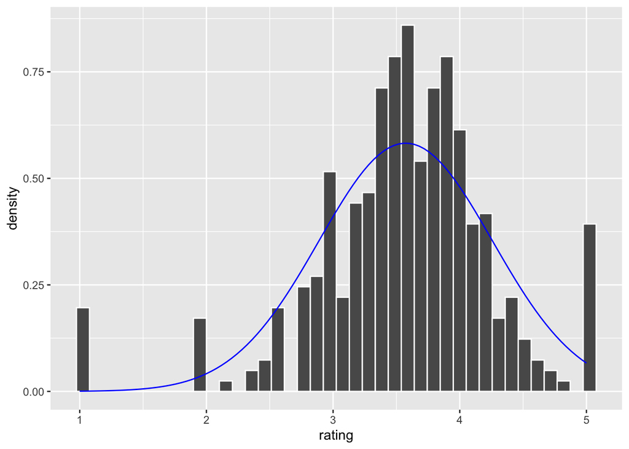

```r
#filter data for top brand
samsung_phones <- phone_data %>%
  filter(brand == "Samsung")

#generate summary stats
samsung_phone_stats <- samsung_phones %>%
  summarise(
    num = n(),
    mean = mean(rating),
    sd = sd(rating)
  )

#plot distribution
samsung_phones %>%
  ggplot(aes(x = rating)) +
  geom_histogram(aes(y = ..density..), col = "white", bins = 40) +
  stat_function( #use this to plot the norm distrib over the histogram
    fun = dnorm,
    args = list(
      mean = samsung_phone_stats$mean,
      sd = samsung_phone_stats$sd
    ),
    col = "blue"
  )
```

The probability density of ratings for the top brand (Samsung) shows a slight left skew. The fitted normal distribution does not show a good fit to the data. There are some outliers seen in the plot as grey peaks which are found outside of the fitted normal distribution which is shown as a blue line.

### Question 4

**We can be more quantitative in comparing the distribution of top brand ratings with a normal distribution. You calculated the `mean()` and `sd()` of your distribution in an earlier question. Use these values to calculate the *proportions* of ratings within one-, two- and three standard deviations of the mean. Compare these proportions with those you expect for a normal distribution.**

```r
#function to calculate proportion of data within x sd from the mean
prop_within_n_sd_calculator <- function(data, n){
  data %>%
    filter(rating >= samsung_phone_stats$mean - n*samsung_phone_stats$sd,
         rating <= samsung_phone_stats$mean + n*samsung_phone_stats$sd) %>%
  summarise(prop_within_sd = n()/samsung_phone_stats$num) %>%
    pull()
}

#generate table with expected proportions for a normal distribution
prop_table <- tibble(
within_1_sd = (pnorm(q = 1) - pnorm(q = -1)),
within_2_sd = (pnorm(q = 2) - pnorm(q = -2)),
within_3_sd = (pnorm(q = 3) - pnorm(q = -3)),
distrib = "normal_distrib_prop"
)

#generate table with proportions from mean from the data
prop_table_data <- tibble(
within_1_sd = prop_within_n_sd_calculator(samsung_phones, 1),
within_2_sd = prop_within_n_sd_calculator(samsung_phones, 2),
within_3_sd = prop_within_n_sd_calculator(samsung_phones, 3),
distrib = "data_distrib_prop"
)

final_table <- bind_rows(prop_table, prop_table_data)
final_table
```

| within_1_sd | within_2_sd | within_3_sd | distrib |
| --- | --- | --- | --- |
| 0.6826895 | 0.9544997 | 0.9973002 | normal_distrib_prop |
| 0.7934509 | 0.9193955 | 0.9798489 | data_distrib_prop |

This data has a proportion of 0.79 of the data within 1 standard deviations (sd) away from the mean, a proportion of 0.92 of the data within 2 sd from the mean and 0.98 of the data within 3 sd of the mean. For an ideally normally distributed data with a mean of 0, a proportion of 0.68 of the data should be distributed within 1 sd of the mean, a proportion of 0.95 of the data should be distributed within 2 sd of the mean and a proportion of 0.99 of the data should be distributed within 3 sd of the mean.

Taking all this information together, I would say this suggests that the distribution of the data is not normally distributed.

## Extention

**Investigate the use of the `qqnorm()` plot in R to determine whether data is normally distributed.**

#### Q-Q plot

The quantile-quantile plot is a visual check of normality. It is a scatterplot of quantiles from the sample distribution on y-axis and theoretical normally distributed quantiles on the x axis.  
If the data is normally distributed the Q-Q plot will form a diagonal line which is almost straight.  
Quantiles are points in the data below which a known proportion of the data points will fall.  
E.g. For a classic normal distibution with a mean of 0 has the 0.5 quantile or 50th percentile at the point at which half the data will like below 0.

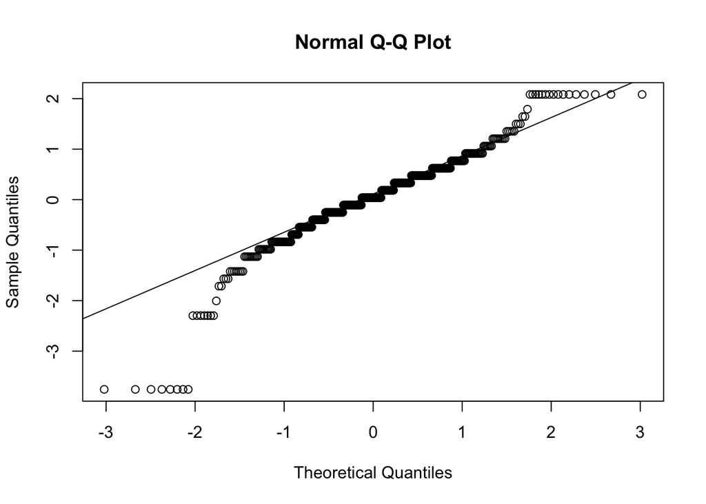

```r
#get the z-score for samsung ratings
samsung_phones<- samsung_phones %>%
  mutate(z_rating = scale(rating))

#generate the Q-Q plot
qqnorm(samsung_phones$z_rating)
qqline(samsung_phones$z_rating)
```

The samsung phone rating data distribution is showing that the points fall on the qqline at the middle of the graph, but deviate at the ends. This indicates that the data has longer tails than would be expected for data from a normally distributed data set. Therefore, the Q-Q plot supports our earlier conclusions that the data is not following a normal distribution.